# Restauration d’image grâce aux chaînes de markov

Clément Thion

06/2020

# Introduction

L’objectif final de ce stage est de restaurer algorithmiquement des images binaires (assez simples) en noir et blanc ayant subi un bruitage. Pour cela on utilise les chaînes de Markov et des modèles énergétiques sur les images, principalement le modèle d’Ising et la mesure de Gibbs, afin de pouvoir estimer de manière probabiliste les meilleures configurations pour la restauration. Les algorithmes ainsi constitués sont ensuite codés en R pour être testés.

Dans dans son état actuel, ce rapport aborde plusieurs questions en lien avec le sujet mais est très loin d’être complet. Une grande part des observations sont encore d’ordre empirique et nécessiteraient d’être approfondies sur le plan théorique. Pour autant on dispose déjà de plusieurs algorithmes fonctionnels permettant une restauration satisfaisante d’images simples.

## Modélisation d’une image

Afin de pouvoir manipuler des images, on utilise les notations et appellations suivantes:  
- x : une configuration d’une grille de pixels donnée (une image donc), parmis l’ensemble des configurations possibles $\Omega$. On note X la variable aléatoire décrivant x.  
- s : un pixel de l’image (on appelle aussi les pixels des “sites”), avec $x_s$ sa valeur. $x_s\in E$ l’ensemble des valeurs possibles d’un pixel. E varie selon le type d’image (couleur, noir et blanc). Pour faciliter le travail, on ne manipule ici que des images en noir et blanc, donc $E=\{-1,1\}$.On note $X_s$ la variable aléatoire décrivant les différents états de $x_s$.  
- $X^s$ :la variable aléatoire décrivant la configuration de l’image privée de $s$. $x^s$ est donc une fonfiguration x donnée, privée de s.  
- $V_s$ : le voisinage de s, que l’on définira plus tard. $V_s^h$ et $V_s^v$ sont respectivement les voisinages sur l’orizontale et la verticale de s.  
- $U$ : le potentiel d’un pixel ou d’une image dans une configuration donnée, appelé aussi énergie.

## Le modèle d’Ising

Afin de calculer des probabilités sur les configurations possibles, on introduit la notion de potentiel U. Le potentiel d’une configuration de pixels, que ce soit l’image en entier ou localement un pixel de l’image et son voisinage, c’est une valeur numérique qui dépend des valeurs des pixels de la configuration.

Il existe plusieurs modèles pour le calculer, et celui que l’on utilisera est le modèle d’Ising.

$$U(x_s) = -\beta x_s \sum_{t\in V_s}{x_t} -B\sum_{s\in S}{x_s}$$

Littéralement, le potentiel de s quand $X=x_s$ est la somme de la valeur des états de ses voisins multiplié par un facteur $-\beta$, plus la somme des valeurs de tous les sites de l’image multiplié par un facteur $-B$.

## La mesure de Gibbs

Maintenant, comment utiliser ce calcul de potentiel local pour calculer les probabilités qui nous intéressent ? Considérons une image bruitée; la première idée qu’il vient pour retrouver la bonne image est d’essayer une par une toutes les configurations de $\Omega$, mais ce n’est pas envisageable devant son cardinal. Rien que pour une image en noir et blanc on part déjà sur des puissances de deux, une petite image de sept cent vingt pixels aura $2^{720}$ configurations différentes…

Pour autant si on voulait essayer il existe un outil, la mesure de Gibbs, qui permet justement de calculer la probabilité $P(X=x)$.

$$P(X=x)=\frac{1}{Z}e^{-U(x)}$$
.

Cependant $Z=\sum_{x\in \Omega}e^{-U(x)}$ représente une somme beaucoup trop grande pour être calculée en pratique, justement à cause de la taille de $\Omega$.

## L’hypothèse markovienne et mesure de Gibbs locale

Pour pallier au problème, une autre approche aussi intuitive pour restaurer cette image consiste à restaurer chaque pixel de l’image un par un, plutôt que considérer l’image dans son ensemble directement.

A priori pour “deviner” quelle est la bonne valeur pour un pixel s, le mieux à faire est de regarder tout le reste de l’image $x^s$, et à partir de $x^s$ essayer d’exprimer $X_s$ pour trouver quelle valeur $x_s$ est la plus probable sachant $x^s$. Cependant, on fait l’hypothèse que connaître $V_s$ le voisinage proche de s est équivalent à connaître $x^s$, soit $P(X_s=x_s| X^s) = P(X_s=x_s|V_s)$. C’est l’hypothèse de Markov, et elle est assez naturelle quand on observe une image; un pixel blanc isolé avec autour de lui seulement des pixels rouges est une situation assez rare, les différentes parties de couleur uniforme d’une image étant souvent grandes de plusieurs pixels, d’autant plus pour une image en noir et blanc dépourvue de dégradé. Faire l’hypothèse de Markov ne semble donc pas à priori ridicule. Et c’est grâce à cette hypothèse que l’on peut utiliser la mesure de Gibbs pour le calcul de potentiel local.

En appliquant la formule de Bayes à $P(X_s=x_s|X^s=x^s)$, on obtient après démonstration:

$$P(X_s=x_s|X^s=x^s) = \frac{exp(-U(x_s|x^s))}{\sum_{\lambda \in E}exp(-U(\lambda |x^s))}$$

et avec l’hypothère markovienne:

$$P(X_s=x_s|X^s=x^s) = P(X_s=x_s|V_s) = \frac{exp(-U(x_s|V_s))}{\sum_{\lambda \in E}exp(-U(\lambda |V_s))}$$

La définition de $V_s$ peut varier, par son étendue et sa forme; le voisinage que nous utiliserons presque toujours est simplement l’ensemble des quatre plus proches voisins de s sur la verticale et l’horizontale. On essaira par la suite de modifier ce voisinage.

## Adapation à la restauration d’image

Pour la restaurer une image, on comprend qu’il manque quelque chose au modèle d’Ising. Tel qu’il est, l’image bruitée initiale n’entre pas en ligne de compte pour le calcul du potentiel local. Et étant donné que c’est la configuration de plus basse énergie qui est la plus probable, avec ce modèle toute image bruitée devrait logiquement être restaurée en une l’image blanche ou un damier de pixel, qui sont bien les configurations de plus basse énergie selon le signe de $\beta$. Il faut donc ajouter un terme au modèle d’Ising pour que l’image bruitée initiale entre en ligne de compte. On pose: $U(x_s) = -\beta\ x_s\sum_{t\in V_s}{x_t}-B\ \sum_{s\in S}{x_s}-\alpha\ x_sx_s^0$ avec $x_s^0$ la valeur du site s de l’image bruitée initiale, et $\alpha$ le facteur qui déterminera le poid que l’on accorde à la configuration initiale.

# Des algorithmes pour la restauration d’image: Gibbs et Metropolis

### L’algorithme de Gibbs

**étape 1** Tirage d’un site comme pour Metropolis  
**étape 2** Calcul des potentiels pour toutes les valeurs de E  
**étape 3** Calcul de la probabilité conditionnelle locale $P(X_s=x_s|V_s)=\frac{exp(-U(x_s|V_s))}{\sum_{\lambda \in E}exp(-U(\lambda|V_s))}$ **étape 4** Simulation de la loi ainsi faite, par tirage aléatoire, et mise à jour du site

## Codage en R

### Boite à outils

Avant de commencer à coder ces algorithmes, on a décidé de créer quelques fonctions utiles pour faciliter la manipulation du code, et son amélioration.

```r
bruiteur=function(image, br, p){
  #fonction qui revoit l'image donnée en argument par la même image mais bruitée par la méthode demandée "br"
  imgBr <- image
  N <- dim(image)[1]
  bruit <- 0
  p <- 0.15
  #----binomiale----
  if(br== "rbinom"){bruit <- matrix(2*rbinom(N^2,1,1-p)-1,nrow=N,ncol=N)}

  #----poisson----      #futurs bruitages différents possibles
  #----normale----

  imgBr <- image*bruit
  return(imgBr)
}#func

#================================================================================================================

imageGenerator=function(forme, N){
  #fonction permettant de générer une matrice-image de forme choisie, et de taille N*N

  img <- matrix(-1, nrow= N, ncol= N)

  #----rectangle----
  if(forme== "rectangle"){
    img[(N/4):(N*3/4),(N/4):(N*3/4)] <- 1}

  #----losange----
  if(forme== "losange"){
    for (i in 1:N){
      for (j in 1:N){
        img[i,j]=-1+2*(abs(i-j)<=N/4)*(abs(i+j-N)<=N/4)
      }}#for#for
  }#if

  #----bandes horizontales----
  if(forme=="bande"){
    for (j in 1:(N/2)){ img[,2*j]=rep(1,N) }
  }#if

  #----bandes verticales----
  if(forme=="bandeV"){
    for (i in 1:(N/2)){ img[2*i,]=rep(1,N) }
  }#if

  return(img)
}#func

#================================================================================================================

correspondance=function(img0, img1, N){
  #fonction qui renvoit le pourcentage de correspondance entre deux images de mêmes tailles.

    nok <- 0 #nombre de pixels divergents

    for (i in (1:N)){
        for (j in (1:N)){
            if(img0[i,j] != img1[i,j]){nok <- nok+1}
        }#for
    }#for
    correspondance <- ((N^2)-nok)/(N^2)*100
    return(correspondance)
}#func
```

### L’algorithme de Gibbs

On propose un code en R pour l’algorithme de Gibbs. Des raccourcis ont été possibles du fait que s ne puisse prendre que deux états en tout (-1 ou 1). Si on voulait un jour passer à des images en nuance de gris ou même en couleur, il faudrait faire des modifications.

```r
gibbsIsing = function(forme, N, p, B, beta, alpha, n){
  # fonction qui réalise l'échantilloneur de Gibbs, sur le modèle d'Ising, avec une image img1 bruitée à partir de img0, afin de restaurer cette image.

  #----création de l'image parfaite img0----
  img0 = imageGenerator(forme, N)
  #----création de l'image bruitée, avec ajout d'une bordure.
    img1 = matrix(0, nrow=N+2, ncol=N+2)
    img1[2:(N+1),2:(N+1)] = bruiteur(img0, "rbinom", p)
    img2 = img1 #image tampon
  img3 = img1 #mémoire du bruit initiale

  for(k in 1:n){ #n parcours de pixels
    #----choix d'un site au hasard---
    i <- 1+ceiling(N*runif(1)) # indice entre 2 et N+1 pour éviter le contour
    j <- 1+ceiling(N*runif(1))

    #----changement de valeur au site choisi sur img2 (1 ou -1) pour représenter E en entier avec img1 et img2 (cas d'une image en noir et blanc)----
    img2[i,j] = -img1[i,j]

    #----voisinage----
    v = img1[i+1,j] + img1[i-1,j] + img1[i,j+1] + img1[i,j-1]

    #----potentiels (modele d'ising)----
    U1 = -B*img1[i,j]-img1[i,j]*(beta*v + alpha*img3[i,j])
    U2 = -B*img2[i,j]-img2[i,j]*(beta*v + alpha*img3[i,j])

    #----calcule de la proba conditionnelle locale----
    P <- exp(-U2)/(exp(-U1)+exp(-U2))

    if(runif(1)<= P){img1[i,j]= img2[i,j]}#on change la valeur du pixel
    else{img2[i,j] <- img1[i,j]} #on garde la valeur du pixel
  }#for

  #----affichage----
  par(mfrow=c(1,3))

  img3 <- img3[2:(N+1),2:(N+1)] #on retire les contours
    img1 <- img1[2:(N+1),2:(N+1)]

    image(1:N,1:N,img0)#image initiale
    image(1:N+2,1:N+2,img3)#image bruitée
    image(1:N+2,1:N+2,img1)#image restaurée
}
```

### L’algorithme de Metropolis

Assez similaire au code pour l’algorithme de Gibbs, voici une proposition de code pour l’algorithme de Metropolis.

```r
metropolisIsing=function(forme, N, p, B, beta, alpha, n){
    #fonction qui réalise l'algorithme de Metropolis sur une image bruitée img1 (à partir de img0), pour restaurer cette image.

    #----création de l'image parfaite img0----
    img0 = imageGenerator(forme, N)

    #----création d'une image auxiliaire img1, avec bord plus long et bruitage----
    img1 = matrix(0, nrow=N+2, ncol=N+2)
    img1[2:(N+1),2:(N+1)] = bruiteur(img0, "rbinom", p)
    img2 = img1 #image tampon
    img3 = img1 #mémoire du bruit initiale

    for(k in 1:n){ #n visites de pixels

        #----choix d'un pixel au hasard----
        i <- 1+ceiling(N*runif(1)) # indice entre 2 et N+1
        j <- 1+ceiling(N*runif(1))

        #----tirage nouvelle valeure candidate----
        img2[i,j] = -img1[i,j]

        #----voisinage----
        v = img1[i+1,j] + img1[i-1,j] + img1[i,j+1] + img1[i,j-1]

        #----potentiels----
        U1 = -B*img1[i,j]-img1[i,j]*(beta*v + alpha*img3[i,j])#potentiel actuel
        U2 = -B*img2[i,j]-img2[i,j]*(beta*v + alpha*img3[i,j])#potentiel candidat

        #----proba conditionnelle locale----
        dU = U2-U1
        p <- exp(-dU)

        if(runif(1)<=p){img1[i,j]= -img1[i,j]}#on change la valeur du pixel
        else{img2[i,j] <- img1[i,j]} #on garde la valeur du pixel
    }#for

    #----affichage----
    img3 <- img3[2:(N+1),2:(N+1)] #on retire le contour
    img1 <- img1[2:(N+1),2:(N+1)]

    par(mfrow=c(1,3))
    image(1:N,1:N,img0)#image initiale
    image(1:N+2,1:N+2,img3)#image bruitée
    image(1:N+2,1:N+2,img1)#image restaurée
    return(c("pourcentage de restauration par metropolisIsing", correspondance(img0,img1,N)))

}#func
```

## Test des codes et observation des résultats

Etant donné que les deux algorithmes sont assez similaires, dans la suite du rapport on utilisera uniquement le code de Metropolis pour les tests.

> **Le paramètre alpha** détermine l’importance donnée à l’image bruitée initiale dans la probabilité conditionnelle $P(X_s=x_s|V_s)$.  
> Si alpha est trop grand devant $\beta$, les valeurs les plus probables seront toujours celles de l’image bruitée, et donc l’algorithme ne fera rien. Un exemple avec $\alpha = 5$ et $\beta = 1$, on voit en effet que l’image restaurée (à droite) n’est presque pas différente de celle bruitée:

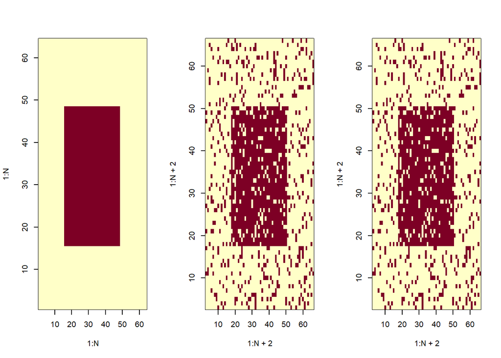

```
## [1] "pourcentage de restauration par metropolisIsing"
## [2] "86.1328125"
```

> Si $\alpha$ est trop petit voir nul, la configuration initiale va être oubliée itération après itération (on retombe sur le modèle d’Ising initial), et on va tendre vers l’image blanche, peu importe l’image de départ. Exemple avec $\alpha=0$, pour deux images différentes: on voit bien que les formes commencent à être détruites.

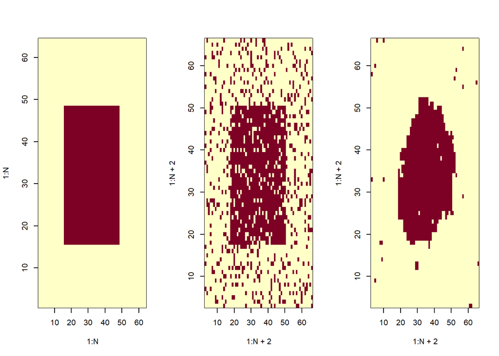

```
## [1] "pourcentage de restauration par metropolisIsing"
## [2] "92.1875"
```

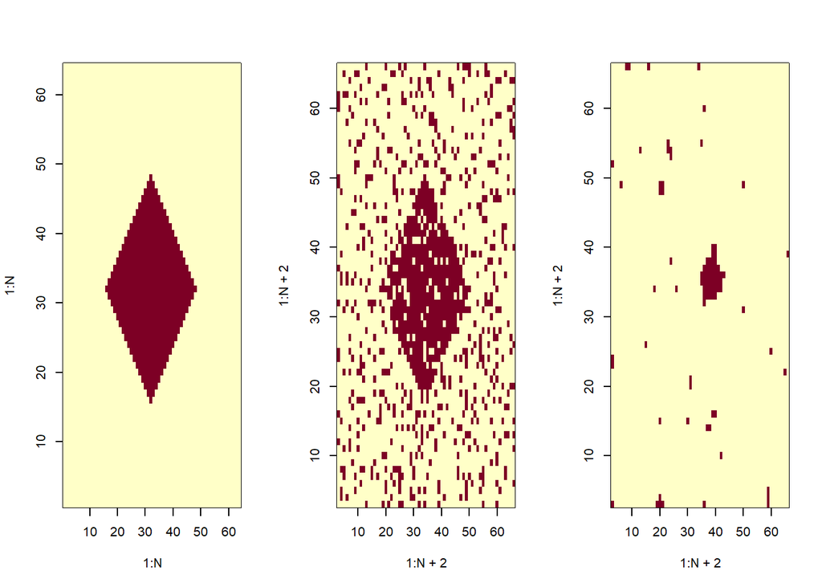

```
## [1] "pourcentage de restauration par metropolisIsing"
## [2] "86.8408203125"
```

> **Le paramètre $\beta$** quant à lui détermine quels motifs seront les plus probables, entre des pixels de mêmes valeurs ($\beta > 0$) ou bien une alternance de pixel banc et noir ($\beta < 0$). Par exemple pour restaurer le rectangle, on constate bien que le $\beta$ positif est nettement préférable au $\beta$ négatif, du fait que le rectangle est une image d’un seul bloc. Illustration avec $\beta=+-0.66$

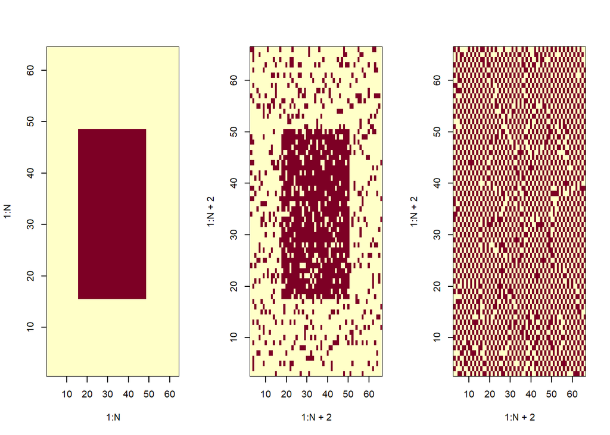

```
## [1] "pourcentage de restauration par metropolisIsing"
## [2] "50.927734375"
```

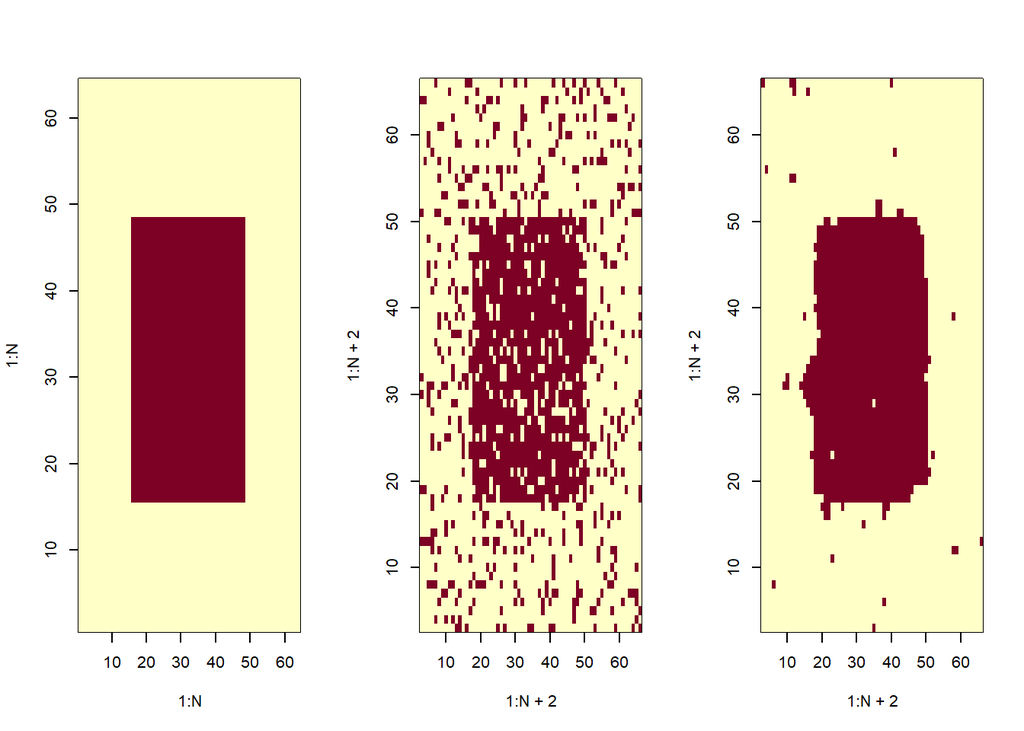

```
## [1] "pourcentage de restauration par metropolisIsing"
## [2] "97.607421875"
```

> **Le calcul du voisinage** se fait assez facilement en R, on regarde la valeur des quatre pixels à gauche, à droite, en haut et en bas du pixel.

> **Le parcours des sites_** peut se faire soit aléatoirement, soit systématiquement (ligne par ligne par exemple).

## Le recuit simulé

Il existe un autre algorithme sur la base de l’algorithme de métropolis, plus performant, et que l’on retrouve imanquablement dans la littérature sur le sujet, c’est l’algorithme de recuit simulé. Par rapport à Metropolis, on introduit une “température”, c’est à dire un paramètre T qui va intervenir dans le calcul de la probabilité comme $P_T(X=x)=\frac{exp(\frac{-U(x)}{T})}{\sum_{\lambda \in S}exp(\frac{-U(\lambda)}{T})}$. Le rapport de métropolis devient alors $exp(\frac{U(x_s)-U(\lambda)}{T})$. Après chaque itération, on fait tendre T un peu plus vers 0. Le principe est que, en partant d’un T “grand” et en le faisant tendre “lentement” vers 0, on doit nécessairement tendre vers le minima global d’énergie.  
Reste à déterminer quelle valeur de T choisir au départ comme étant grande, à quelle vitesse le faire tendre vers 0… Pour l’instant on fait ces choix arbitrairement et en s’inspirant de la littérature sur le sujet. Il reste aussi à démontrer dans ce rapport comment modifier les paramètres à chaque itération permet de converger presque sûrement vers le minimum global d’énergie.

```r
recuitSimule=function(forme, N, p, B, beta, alpha, n){
    #fonction qui réalise l'algorithme de recuit simulé, pour restaurer img1

    #----création de l'image parfaite img0----
    img0 = imageGenerator(forme, N)

    #----création d'une image auxiliaire img1, avec bordure et bruit----
    img1 = matrix(0, nrow=N+2, ncol=N+2)
    img1[2:(N+1),2:(N+1)] = bruiteur(img0, "rbinom", p)
    img2 = img1 #image tampon
    img3 = img1 #mémoire du bruit initiale

    for(k in 1:n){ #n visites de pixels

      T <- 1/log(k+1) #T tend lentement vers 0

        #----choix d'un pixel au hasard----
        i <- 1+ceiling(N*runif(1)) # indice entre 2 et N+1
        j <- 1+ceiling(N*runif(1))

        #----tirage nouvelle valeure candidate----
        img2[i,j] = -img1[i,j]

        #----voisinage----
        v = img1[i+1,j] + img1[i-1,j] + img1[i,j+1] + img1[i,j-1]

        #----potentiels----
        U1 = -B*img1[i,j]-img1[i,j]*(beta*v + alpha*img3[i,j])#potentiel actuel
        U2 = -B*img2[i,j]-img2[i,j]*(beta*v + alpha*img3[i,j])#potentiel candidat

        #----probabilité conditionnelle locale, "recuite" à chaque itération----
        dU = U2-U1
        p <- exp(-dU/T)

        if(runif(1)<=p){img1[i,j]= -img1[i,j]}#changement
        else{img2[i,j] <- img1[i,j]} #inchangé
    }#for

    #----affichage----
    img3 <- img3[2:(N+1),2:(N+1)] #retire le contour
    img1 <- img1[2:(N+1),2:(N+1)]

    par(mfrow=c(1,3))
    image(1:N,1:N,img0)#image initiale
    image(1:N+2,1:N+2,img3)#image  bruitée
    image(1:N+2,1:N+2,img1)#image restaurée
    return(c("pourcentage de restauration par recuitSimule", correspondance(img0,img1,N)))

}#func
```

> **Comparaison de performance** On constate que la différence de performance de restauration est quasiment nulle entre les deux algorithmes. Cela s’explique peut être du fait de la simplicité de l’image à restaurer. Dans le cas d’une image plus complexe, le recuit simulé devrait toujours nous ramener vers la configurations d’énergie minimale, tandis que Metropolis pourra parfois rester piégé dans des minima locaux d’énergie.

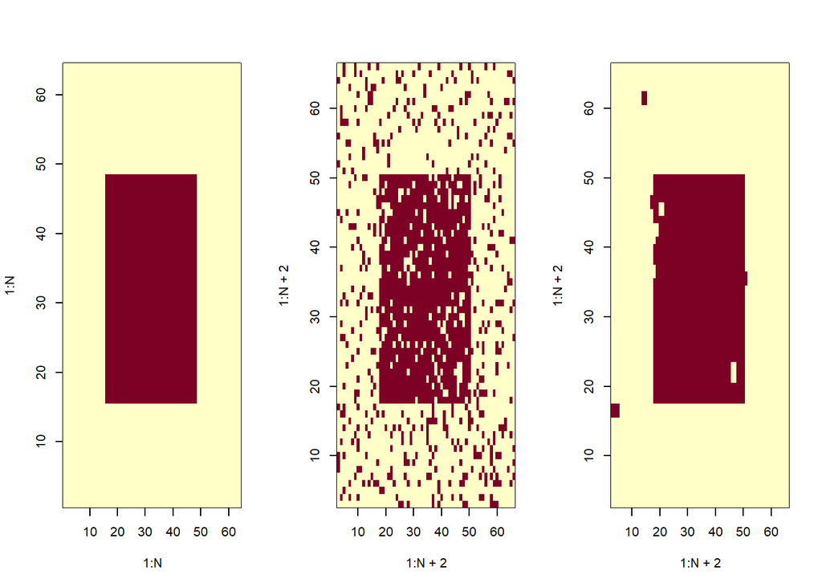

```
## [1] "pourcentage de restauration par recuitSimule"
## [2] "99.2431640625"
```

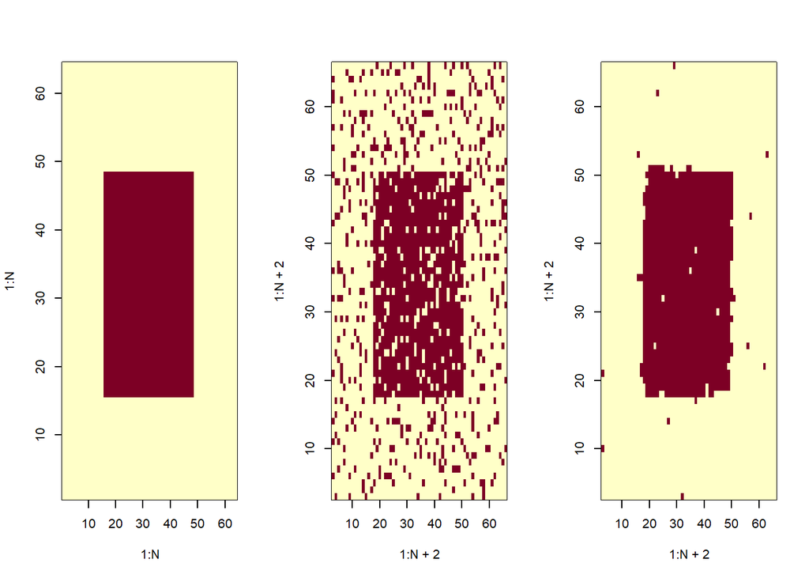

```
## [1] "pourcentage de restauration par metropolisIsing"
## [2] "98.3642578125"
```

# Estimation du paramètre $\beta$

L’algorithme de recuit précédent marche plutôt bien pour des images pleines (rectangle, losange), mais si on éssaie de restaurer une image en plusieurs parties, une succession de bandes par exemple, ou un damier, l’algorithme ne fonctionne plus du tout, peu importe le signe de $\beta$ :

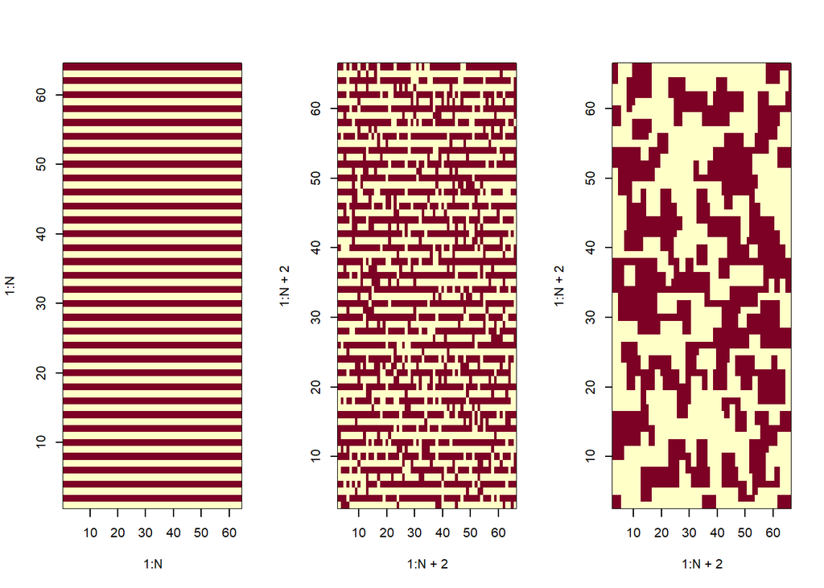

```
## [1] "pourcentage de restauration par recuitSimule"
## [2] "59.4482421875"
```

```r
recuitSimule("bande", 64, 0.25, 0, 0.66, 0.33, 5*10^4)
```

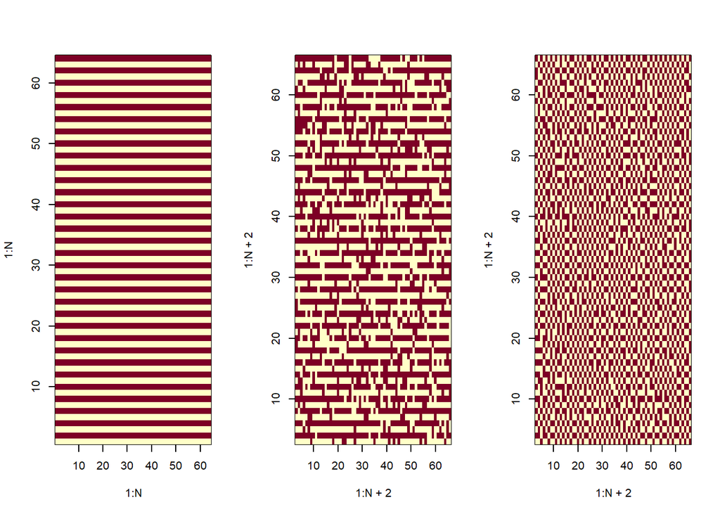

```
## [1] "pourcentage de restauration par recuitSimule"
## [2] "57.9833984375"
```

```r
recuitSimule("bande", 64, 0.25, 0, -0.66, 0.33, 5*10^4)
```

## Distinction des énergies verticales et horizontales

Une idée que l’on peut avoir pour pallier au problème est de séparer les calculs de potentiels entre la verticale et l’horizontale, en appliquant à chaque terme un facteur $\beta$ dédié à une orientation. On modifie l’algorithme de recuit pour essayer, en changeant le code comme suit:

- le calcul de voisinage est divisé en deux termes, les voisins sur l’horizontale Vh et ceux sur la verticale Vv.
- Le terme concernant le voisinage dans le calcul de U est maintenant scindé en deux, avec deux $\beta$ différents, $\beta_h$ pour l’horizontale et $\beta_v$ pour la verticale. On a ainsi: $U(x_s)= -x_s[\beta_h(x_d+x_g)+\beta_v(x_h+x_b)+\alpha x_s^0]$ avec $x_d,x_g,x_h,x_b$ les valeurs des pixels voisins du site s respectivement à droite, gauche, haut, bas.
- Les signes respectifs des deux $\beta$ sont calculés automatiquement en faisant une analyse du signe global de l’image sur l’orizontale et la verticale. Pour ce faire on utilise la fonction ernergiehv(), qui réalise les sommes des doubles produits des couples de pixels voisins, sur la verticale pour une somme et sur l’horizontale pour l’autre. Dans le cas des bandes horizontales par exemple, on voudrait avoir un $\beta_h>0$ et un $\beta_v<0$. En effet une ligne horizontale de l’image est constituée de pixels identiques, on veut donc que soit privilégiée l’égalité de valeur entre $x_s$ et $x_t,\ t\in V_s^h$, avec $V_s^h$ le voisinage de s sur l’horizontale. Sur une ligne verticale, c’est l’inverse.

```r
restorStripe=function(forme, N, p, B, beta, alpha, n){
  #fonction de recuit simulé modifiée pour restaurer une image en bandes horizontales noir et blanche alternées, grâce à une
  #disjonction de cas entre l'horizontale et la verticale pour les calculs de potentiel.

  energiehv=function(img){
    #fonction qui renvoie, dans un tuple, les sommes des doubles produits sur les lignes, et sur les colonnes. Le résultats sert
    #au calcul des betah et betav
    eligne=0
    ecolonne=0
    for (i in 1:N) {for (j in 1:(N-1)){eligne=eligne+img[i,j]*img[i,j+1]}}  #somme des doubles produits de ligne
    for (j in 1:N) {for (i in 1:(N-1)){ecolonne=ecolonne+img[i,j]*img[i+1,j]}}  #somme des doubles produits de colonne
    return(c(eligne,ecolonne))
  }#func


  #----img0, initiale----
  img0 = imageGenerator(forme, N)

  #----img1, avec bordure et bruit----
  img1 = matrix(0, nrow=N+2, ncol=N+2)
  img1[2:(N+1),2:(N+1)] = bruiteur(img0, "rbinom", p)
  img2 = img1 #tampon
  img3 = img1 #bruit initiale

  #----calcul des deux beta, horizontale et verticale----
  betah=2*energiehv(img1)[2]/(abs(energiehv(img1)[1])+abs(energiehv(img1)[2]))
  betav=2*energiehv(img1)[1]/(abs(energiehv(img1)[1])+abs(energiehv(img1)[2]))

    for(k in 1:n){ #n visites de pixels

      T <- 1/log(n)

        #----choix d'un pixel au hasard----
        i <- 1+ceiling(N*runif(1))
        j <- 1+ceiling(N*runif(1))

        #----tirage nouvelle valeure candidate----
        img2[i,j] = -img1[i,j]

    #----calcule du voisinage séparément entre horizontale (Vh) et verticale (Vv)
    Vh <- img1[i-1,j]+img1[i+1,j]
    Vv <- img1[i,j-1]+img1[i,j+1]

        #----potentiels----
        U1 = -B*img1[i,j]-img1[i,j]*(betah*Vh + betav*Vv + alpha*img3[i,j])#potentiel actuel
        U2 = -B*img2[i,j]-img2[i,j]*(betah*Vh + betav*Vv + alpha*img3[i,j])#potentiel candidat

        #----test----
        dU = U2-U1
        p <- exp(-dU/T)

        if(runif(1)<=p){img1[i,j]= -img1[i,j]}#changé
        else{img2[i,j] <- img1[i,j]} #inchangé
    }#for


  #----affichage----
  img3 <- img3[2:(N+1),2:(N+1)]
  img1 <- img1[2:(N+1),2:(N+1)]
  par(mfrow=c(1,3))
  image(1:N,1:N,img0)#image initiale
  image(1:N+2,1:N+2,img3)#image bruitée
  image(1:N+2,1:N+2,img1)#image restaurée

  return(c("pourcentage de restauration par restorStripe",correspondance(img0,img1,N),"betah",betah,"betav",betav))

}#func
```

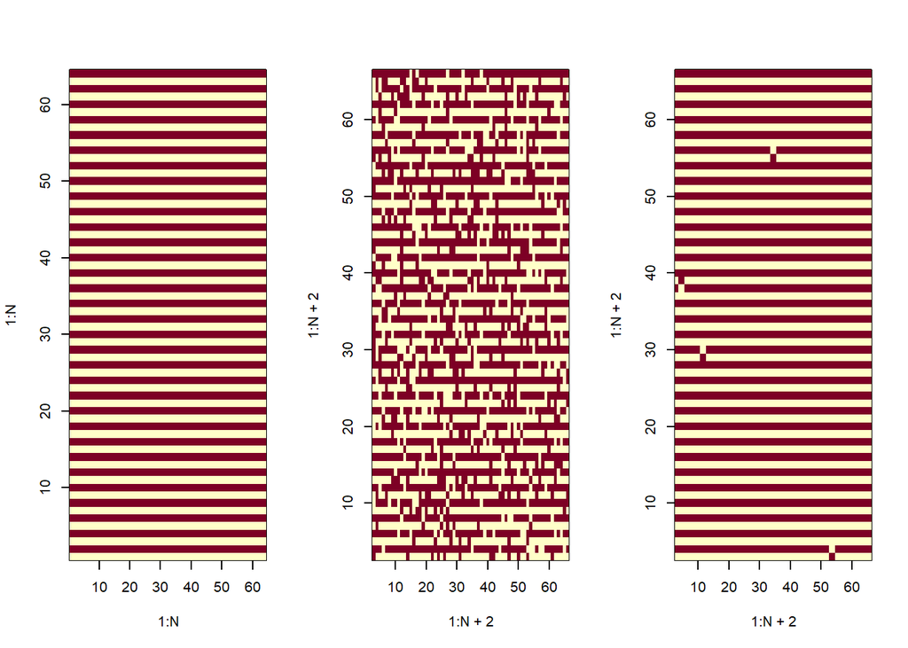

```
## [1] "pourcentage de restauration par restorStripe"
## [2] "99.609375"
## [3] "betah"
## [4] "0.989395546129374"
## [5] "betav"
## [6] "-1.01060445387063"
```

```r
restorStripe("bande",64,0.25,0,0.66,0.33,5*10^4)
```

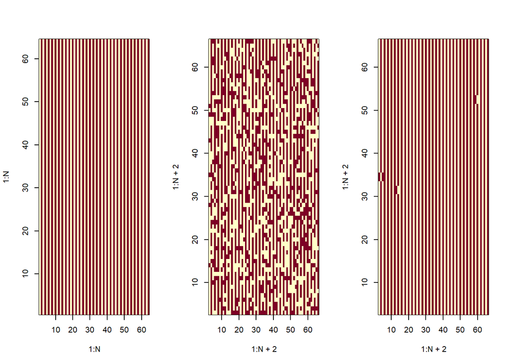

```
## [1] "pourcentage de restauration par restorStripe"
## [2] "99.658203125"
## [3] "betah"
## [4] "-0.984776902887139"
## [5] "betav"
## [6] "1.01522309711286"
```

```r
restorStripe("bandeV",64,0.25,0,0.66,0.33,5*10^4)
```

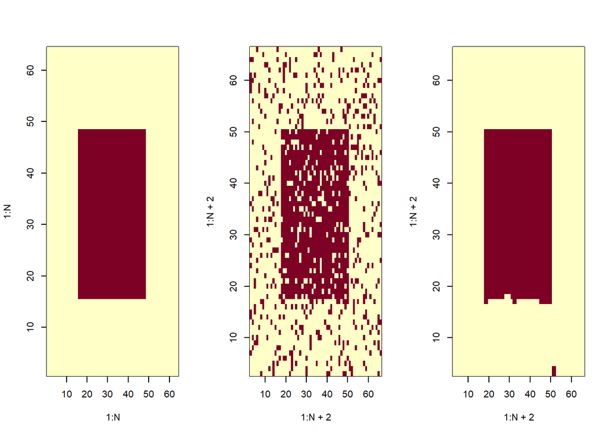

```
## [1] "pourcentage de restauration par restorStripe"
## [2] "99.5849609375"
## [3] "betah"
## [4] "0.994152046783626"
## [5] "betav"
## [6] "1.00584795321637"
```

```r
restorStripe("rectangle",64,0.25,0,0.66,0.33,5*10^4)
```

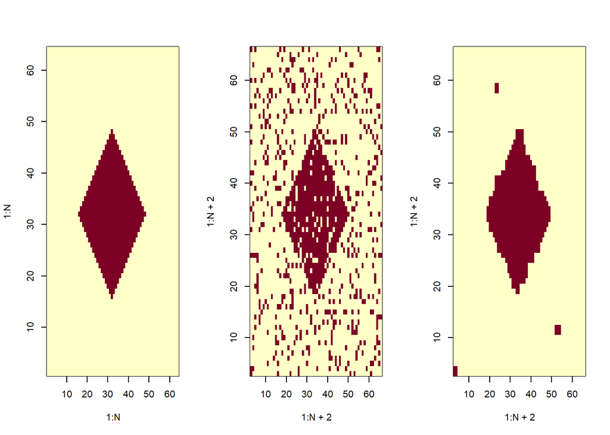

```
## [1] "pourcentage de restauration par restorStripe"
## [2] "98.9013671875"
## [3] "betah"
## [4] "0.994321115126484"
## [5] "betav"
## [6] "1.00567888487352"
```

```r
restorStripe("losange",64,0.25,0,0.66,0.33,5*10^4)
```

On constate que cette fois la restauration se fait très bien tant pour les formes pleines que pour les bandes; l’utilisation de $\beta$ intermédiaires fonctionne, et on remarque bien $\beta_h>0$ et $\beta_v<0$ pour des lignes horizontales, et l’inverse pour des lignes verticales. Pour les formes pleines (losange et rectangle), les deux $\beta$ sont bien positifs, d’où le fait qu’un unique beta positif suffise pour ces images.

## Voisinage de taille variable

Une autre piste à creuser pour répondre au problème de restauration des bandes, ce serait de changer la définition du voisinage. L’idée est la suivante: faire que la taille et la forme du voisinage changent d’un pixel à l’autre. En effet imaginons un pixel de l’image bruitée “bande”. Il y a de grandes chances que la ligne horizontale sur laquelle il se trouve soit à majorité d’une valeur de E, tandis que sur la ligne verticale, de part l’alternance de bandes, on aura à peu près moitié moitié. Ce qu’on aimerait c’est que le voisinage s’étende sur l’horizontale là où les pixels deux à deux sont (souvent) de même valeur, mais qu’il reste petit sur la verticale.

Seuls les pixels sur les lignes verticales et horizontales où se trouve s peuvent faire partie de $V_s$, comme pour le voisinage habituel haut bas gauche droite.

On définit le voisinage comme une étoile à quatre branches, deux sur l’horizontale (une à gauche de s, l’autre à droite), et deux sur la verticale (l’une en haut de s et l’autre en bas). On peut donc voir ce voisinage en étoile comme une extension du voisinage classique.  
La longueur de chaque branche dépend de la continuité des valeurs des pixels depuis s et de proche en proche sur la direction de la branche. Autrement dit, la longueur d’une branche est égale au nombre de pixels côte à côte suivant l’orientation de la branche, de même valeur (pour une image en noir et blanc), partant de s. Ainsi d’un pixel à l’autre on n’aura pas forcément un voisinage de même ampleur.

On peut choisir une longueur maximale pour les branches, une majoration certaine étant la largeur de l’image. C’est d’ailleurs préférable d’un point de vue pratique car plus les branches sont longues plus les calculs le sont aussi.

L’algorithme de Vstar est simple: pour chacun des voisins habituels de s (haut bas gauche droite), on regarde son voisin opposé à s et sur la même direction (le “voisin du voisin”); s’il a la même valeur que le premier voisin, on l’intègre à la branche. Sinon la branche est terminée.

```r
Vstar=function(img, N, i, j, L){
  #fonction qui calcule le voisinage du pixel (i,j), selon le modèle de voisinage en étoile variable.

  vbranch=function(img, N, is, js, iv, jv, L){
      #L détermine la longueur maximale d'une branche
      #(iv, jv) appartient à [(0,1),(0,-1),(1,0),(-1,0)], c'est ce qui donne le sens de la branche à partir de s

      v = c() #branche finale
      vl = c() #branche brute
      if(is<1 | is>N | js<1 | js>N){return("les coordonnées données sont en dehors de l'image")}

      #----récupération des L sites de la branche potentielles sans condition----
      for(k in(1:L)){
          i <- is+k*iv
          j <- js+k*jv
          if(i>=1 && i<=N){ if(j>=1 && j<=N){ #teste si les coordonnées du candidat sont dans l'image
              vl <- c(vl,img[i,j])
          }}#if&if
      }#for
      if(is.null(vl[1])){return(0)} #si on est sur le bord

      #----épuration selon la condition de valeur de site----
      lead <- vl[1] #base de la branche, à côté du site
      for(k in 1:length(vl)){ #parcours les L sites
          if(vl[k]==lead){ v <- c(v,vl[k]) }#condition pour faire partie de la branche.
      }#for

      return(length(v)*lead) #"poid" de la branche. length(v) fait office de facteur, comme beta classiquement
  }#func

  #somme des quatre branches
    s <- 0
    s <- s + vbranch(img, N, i, j, -1, 0, L)
    s <- s + vbranch(img, N, i, j, 1, 0, L)
    s <- s + vbranch(img, N, i, j, 0, -1, L)
    s <- s + vbranch(img, N, i, j, 0, 1, L)
    return(s)
}#func
```

```r
recuitSimule_Vstar=function(forme, N, p, B, beta, alpha, n, L){
    #fonction qui réalise l'algorithme de recuit, mais dont le calcul de voisinage se faite selon le modèle en étoile variable.

    #----image parfaite img0----
    img0 = imageGenerator(forme, N)

    #----image auxiliaire img1, avec bordure et bruitage----
    img1 = matrix(0, nrow=N+2, ncol=N+2)
    img1[2:(N+1),2:(N+1)] = bruiteur(img0, "rbinom", p)
    img2 = img1 #tampon
    img3 = img1 #bruit initiale

    for(k in 1:n){

      T <- 1/log(k+1)

        #----choix d'un pixel au hasard----
        i <- 1+ceiling(N*runif(1))
        j <- 1+ceiling(N*runif(1))

        #----tirage nouvelle valeure candidate----
        img2[i,j] = -img1[i,j]

        #----voisinage selon le modèle en étoile----
      v = Vstar(img1, N+2, i, j, L)

        #----potentiels----
        U1 = -B*img1[i,j]-img1[i,j]*(beta*v + alpha*img3[i,j])#potentiel actuel
        U2 = -B*img2[i,j]-img2[i,j]*(beta*v + alpha*img3[i,j])#potentiel candidat

        #----test----
        dU = U2-U1
        p <- exp(-dU/T)

        if(runif(1)<=p){img1[i,j]= -img1[i,j]}#changé
        else{img2[i,j] <- img1[i,j]} #inchangé
    }#for

    #----affichage----
    img3 <- img3[2:(N+1),2:(N+1)] #on retire le contour
    img1 <- img1[2:(N+1),2:(N+1)]

    par(mfrow=c(1,3))
    image(1:N,1:N,img0)#image initiale
    image(1:N+2,1:N+2,img3)#image  bruitée
    image(1:N+2,1:N+2,img1)#image restaurée

    return(correspondance(img0, img1, N))

}#func
```

Le test de Vstar cependant dans le recuit simulé de fonctionne pas du tout (longueur de branche L=8 pixels):

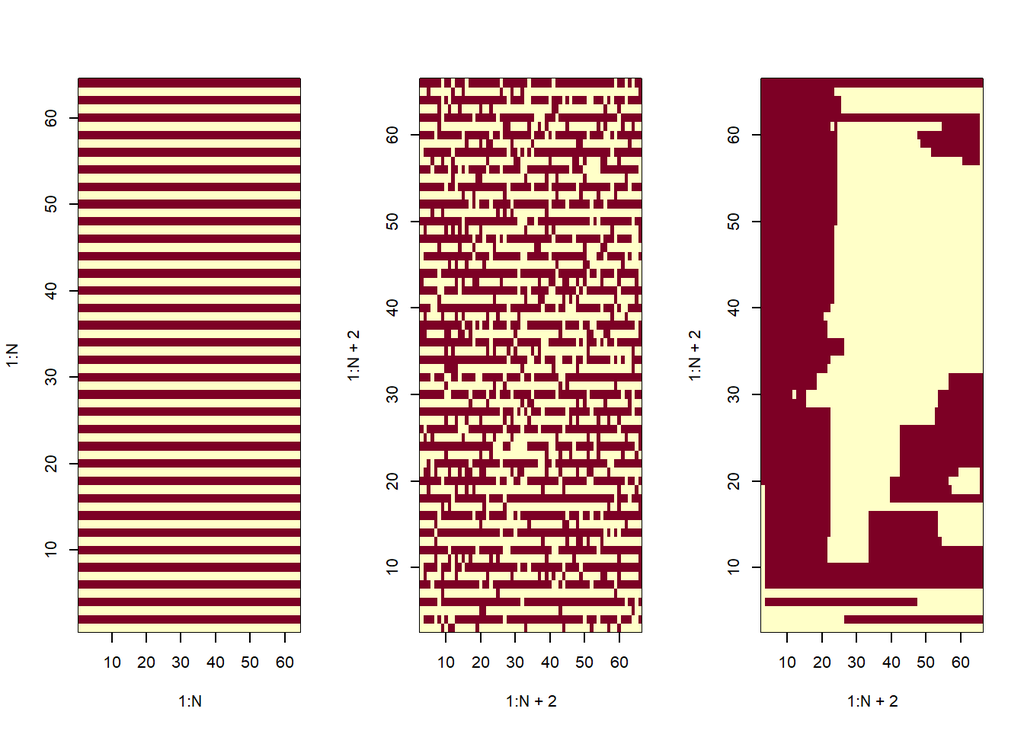

```
## [1] 56.51855
```

```r
recuitSimule_Vstar("bande", 64, 0.25, 0, 0.66, 0.33, 5*10^4, 8)
```

Ce qui ne va pas, c’est que Vstar a été pensé comme condition unique du choix de $x_s$, c’est à dire que l’on voulait $V_s<0 \Rightarrow x_s=-1$ et $V_s>0 \Rightarrow x_s=1$, dans une logique déterministe, sans tenir compte de $x_s^0$. Tel quel donc, dans l’algorithme de métropolis ou de recuit, Vstar ne permet pas de répondre au problème des bandes.

# Amélioration de la rapidité des algorithmes

Depuis le début, on fixe le nombre d’itérations de l’algorithme (souvent à $10^4$ ou $10^5$). Cependant, il est très probable, de part l’avancée aléatoire de l’algorithme de recuit ou de métropolis, et d’autant plus du fait que les images à restaurer sont toutes différentes, que ce ne soit pas nécessaire de faire toujours le même nombre d’itérations pour arriver à restaurer comme on le souhaite.  
Une manière de rendre le nombre d’itérations variable est de le conditionner au nombre de parcours de sites successifs sans changement de valeurs. En effet, si on ne change pas de valeur, c’est normalement parce que cette valeur était la bonne. Donc on introduit un paramètre S tel que, si on ne change plus de valeur S fois de suite, on supposera que l’image entière n’a plus à être modifiée et on arrête l’algorithme.

Pour essayer la condition d’arrêt on modifie un petit peu recuitSimule() pour faire smartStop(). Etant donné que c’est le nombre d’itérations qui nous interesse ici, on a retiré l’affichage des images.

```r
smartStop=function(forme, N, p, B, beta, alpha, S){
    #fonction qui réalise l'algorithme de recuit simulé avec pour condition d'arrêt faire S itérations successives sans changement de valeur.

    #----création de l'image parfaite img0----
    img0 = imageGenerator(forme, N)

    #----création d'une image auxiliaire img1, avec bord plus long et bruitage----
    img1 = matrix(0, nrow=N+2, ncol=N+2)
    img1[2:(N+1),2:(N+1)] = bruiteur(img0, "rbinom", p)
    img2 = img1 #image tampon
    img3 = img1 #mémoire du bruit initiale

  X<-0 #nombre d'itérations consécutives sans changement de spin
  it<-0 #compteur

  while(X<=S) {

    it <- it+1
      T <- 1/log(it+1) #T tend vers 0

        #----choix d'un pixel au hasard----
        i <- 1+ceiling(N*runif(1)) # indice entre 2 et N+1
        j <- 1+ceiling(N*runif(1))

        #----tirage nouvelle valeure candidate----
        img2[i,j] = -img1[i,j]

        #----voisinage----
      v = Vstar(img1, N+2, i, j, 5) # L arbitrairement fixé à 5

        #----potentiels----
        U1 = -B*img1[i,j]-img1[i,j]*(beta*v + alpha*img3[i,j])#potentiel actuel
        U2 = -B*img2[i,j]-img2[i,j]*(beta*v + alpha*img3[i,j])#potentiel candidat

        #----test----
        dU = U2-U1
        p <- exp(-dU/T)

        if(runif(1)<=p){#on change la valeur du pixel
          img1[i,j]= -img1[i,j]
          X <- 0} #on a changé un pixel, retour à la case départ

        else{
          img2[i,j] <- img1[i,j]
          X <- X+1} #on garde la valeur du pixel
    }#for

    #----RETURN----
    img1 <- img1[2:(N+1),2:(N+1)]
    corresp <- correspondance(img0, img1, N)
    return(c(corresp,it)) #(pourcentage de restauration, nombre d'itérations nécessaires)

}#func
```

Pour le test on va lancer plusieurs fois la fonction smartStop() avec des valeurs de S de plus en plus grandes et observer le pourcentage de restauration associé (grâce à correspondance()). On utilise pour cela la fonction suivante:

```r
disp_smartStop=function(forme, N, p, B, beta, alpha, S, pas){

  plage = seq(pas,S,pas) #plage S des tirages successifs sans changement
  l = length(plage)
  corresp = c(1:l) #stock des pourcentages de restauration
  iter = c(1:l) #stock des quantités d'itérations

  for( ss in plage){
    result = smartStop(forme, N, p, B, beta, alpha, ss)
    corresp[ss/pas] <- result[1]
    iter[ss/pas] <- result[2]

  }#for

  rev <- data.frame(plage_evaluation=plage, correspondance=corresp, nombre_iteration=iter )
  print(rev)
}#func
```

On fait le test en partant d’une condition à 200 itérations successives, jusqu’à 2000 itérations successives, par pas de 200:

```r
disp_smartStop("rectangle", 64, 0.25, 0, 0.66, 0.33, 2000, 200)
```

```
##    plage_evaluation correspondance nombre_iteration
## 1               200       97.75391             8827
## 2               400       99.41406            13390
## 3               600       99.12109            12591
## 4               800       99.26758            15269
## 5              1000       99.58496            18291
## 6              1200       99.70703            17290
## 7              1400       99.82910            18546
## 8              1600       99.85352            20764
## 9              1800       99.87793            22812
## 10             2000       99.70703            24432
```

Pour alléger encore davantage la condition d’arrêt et réduire le nombre d’itérations, on peut ajouter une variable de pourcentage d’erreur tolérée prcm; sur les S itérations successives, si on obtient entre 0 et prcm*S changements ($0<prcm<1$), la condition d’arrêt est quand même validée. S’il y a davantage de changements sur les S itérations, la condition n’est pas remplie et l’algorithme continue.

```r
smartStopLight=function(forme, N, p, B, beta, alpha, S, prcm){

    img0 = imageGenerator(forme, N)
    img1 = matrix(0, nrow=N+2, ncol=N+2)
    img1[2:(N+1),2:(N+1)] = bruiteur(img0, "rbinom", p)
    img2 = img1 #image tampon
    img3 = img1 #mémoire du bruit initiale
  X<-0 #nombre d'itérations consécutives sans changement de spin
  Y <- 0 #nombre de changements de spin, remis à 0 dès que Y==m.
  m <- prcm*S #nombre d'erreurs tolérées
  it<-0 #compteur d'itération général
  while(X<=S) {
    it <- it+1
      T <- 1/log(it+1) #T tend vers 0
        i <- 1+ceiling(N*runif(1)) # indice entre 2 et N+1
        j <- 1+ceiling(N*runif(1))
        img2[i,j] = -img1[i,j]
      v = Vstar(img1, N+2, i, j, 5) # L arbitrairement fixé à 5
        U1 = -B*img1[i,j]-img1[i,j]*(beta*v + alpha*img3[i,j])#potentiel actuel
        U2 = -B*img2[i,j]-img2[i,j]*(beta*v + alpha*img3[i,j])#potentiel candidat
        dU = U2-U1
        p <- exp(-dU/T)
        if(runif(1)<=p){#on change la valeur du pixel
          img1[i,j]= -img1[i,j]
          Y <- Y+1
          if(Y==m+1){ #dépassement du cota de changement de valeur m
            X <- 0
            Y <- 0}
          else{X <- X+1}
        }#if
        else{ #on garde la valeur du pixel
          img2[i,j] <- img1[i,j]
          X <- X+1}
    }#for

    #----RETURN----
    img1 <- img1[2:(N+1),2:(N+1)]
    corresp <- correspondance(img0, img1, N)
    return(c(corresp,it)) #(pourcentage de restauration, nombre d'itérations nécessaires)
}#func

#smartStopLight("rectangle", 64,0.25, 0, 2/3, 1/3, 500, 15)
```

On réalise le test du code de la même manière que pour smartStop(), avec les mêmes valeurs, en choisissant $prcm=1\%$.

```r
disp_smartStopLight=function(forme, N, p, B, beta, alpha, S, pas, prcm){

  plage = seq(pas,S,pas) #plage S des tirages successifs sans changement
  l = length(plage)
  error = c(1:l) #stock du nombre d'erreurs maximal accepté
  corresp = c(1:l) #stock des pourcentages de restauration
  iter = c(1:l) #stock des quantités d'itérations

  for( ss in plage){
    #m = prcm*ss
    result = smartStopLight(forme, N, p, B, beta, alpha, ss, prcm)
    error[ss/pas] <- prcm*ss #nombre d'erreurs tolérées
    corresp[ss/pas] <- result[1]
    iter[ss/pas] <- result[2]

  }#for

  rev <- data.frame(plage_evaluation=plage, correspondance=corresp, nombre_iteration=iter, erreur_maximal=error)
  print(rev)
}#func
```

```r
disp_smartStopLight("rectangle", 64, 0.25, 0, 0.66, 0.33, 2000, 200, 0.01)
```

```
##    plage_evaluation correspondance nombre_iteration erreur_maximal
## 1               200       96.75293             6379              2
## 2               400       97.53418             9044              4
## 3               600       97.77832             9696              6
## 4               800       99.16992            12707              8
## 5              1000       98.73047            10591             10
## 6              1200       98.77930            10925             12
## 7              1400       98.73047            11070             14
## 8              1600       98.90137            13297             16
## 9              1800       98.55957            13459             18
## 10             2000       98.36426            10905             20
```

A terme on aimerait pouvoir déterminer a priori, étant donnée l’image bruitée, le nombre minimal d’itérations successives sans modification à réaliser pour une restauration à un certain pourcentage.

## Algorithme d’ICM

Un algorithme de restauration plus rapide que celui de Metroppolis ou de recuit simulé, est l’algorithme d’ICM. Il est très similaire à l’algorithme de Metropolis, si ce n’est que l’on n’autorise pas de remontée d’énergie. Concrètement à chaque itération, on choisira systématiquement dans E la valeur pour $X_s$ la plus probable, soit la valeur amenant s à la plus faible énergie entre les deux valeurs (avec Metropolis, on autorisait quand même possiblement un changement pour un $x_s$ de plus haute énergie, avec pour probabilité l’exponetielle de la variation d’énergie).

On reprend l’algorithme de Metropolis en modifiant la partie de test:

```r
ICM=function(forme, N, p, B, beta, alpha, n){
    #fonction qui réalise l'algorithme d'ICM, pour restaurer img1

    #----création de l'image parfaite img0----
    img0 = imageGenerator(forme, N)

    #----création d'une image auxiliaire img1, avec bordure et bruit----
    img1 = matrix(0, nrow=N+2, ncol=N+2)
    img1[2:(N+1),2:(N+1)] = bruiteur(img0, "rbinom", p)
    img2 = img1 #image tampon
    img3 = img1 #mémoire du bruit initiale

    for(k in 1:n){ #n visites de pixels

        #----choix d'un pixel au hasard----
        i <- 1+ceiling(N*runif(1)) # indice entre 2 et N+1
        j <- 1+ceiling(N*runif(1))

        #----tirage nouvelle valeure candidate----
        img2[i,j] = -img1[i,j]

        #----voisinage----
        v = img1[i+1,j] + img1[i-1,j] + img1[i,j+1] + img1[i,j-1]

        #----potentiels----
        U1 = -B*img1[i,j]-img1[i,j]*(beta*v + alpha*img3[i,j])#potentiel actuel
        U2 = -B*img2[i,j]-img2[i,j]*(beta*v + alpha*img3[i,j])#potentiel candidat

        #----probabilité conditionnelle locale, "recuite" à chaque itération----

        if(U1>U2){img1[i,j]= -img1[i,j]}#le changement proposé fait diminuer le potentiel local, on l'accept
        else{img2[i,j] <- img1[i,j]} #le changement proposé fait augmenter le potentiel local, on le refuse
    }#for

    #----affichage----
    img3 <- img3[2:(N+1),2:(N+1)] #retire le contour
    img1 <- img1[2:(N+1),2:(N+1)]

    return(correspondance(img0,img1,N))

}#func
```

```r
disp_generalSpeedTest=function(forme, N, p, B, beta, alpha, nn, pas){

  iteration = seq(pas,nn,pas) #plage S des tirages successifs sans changement
  l = length(iteration) #nombre de test que l'on va réaliser
  corresp_metro = c(1:l) #stock des pourcentages de restauration pour Metropolis
  corresp_ICM = c(1:l) #stock des pourcentages de restauration pour ICM
  corresp_recuit = c(1:l) #// pour le recuit simulé

  for( n in iteration){
    corresp_metro[n/pas] <- metropolisIsing_return(forme, N, p, B, beta, alpha, n)
    corresp_recuit[n/pas] <- recuitSimule_return(forme, N, p, B, beta, alpha, n)
    corresp_ICM[n/pas] <- ICM(forme, N, p, B, beta, alpha, n)
  }#for

  rev <- data.frame(nombre_iteration=iteration, restauration_Metropolis=corresp_metro, restauration_recuit=corresp_recuit, restauration_ICM=corresp_ICM)

  ggplot(data = rev, aes(x="largeur de la plage",y="nombre d'itération"))+geom_line()+geom_point()
    # + geom_smooth()
  print(rev)
}#func
```

```r
disp_generalSpeedTest("rectangle",64,0.25,0,0.66,0.33,10^5,10^4)
```

```
##    nombre_iteration restauration_Metropolis restauration_recuit
## 1             1e+04                94.82422            97.68066
## 2             2e+04                96.77734            98.87695
## 3             3e+04                97.50977            98.97461
## 4             4e+04                98.02246            98.77930
## 5             5e+04                97.72949            99.19434
## 6             6e+04                98.36426            98.24219
## 7             7e+04                98.02246            99.56055
## 8             8e+04                97.85156            98.99902
## 9             9e+04                97.99805            99.31641
## 10            1e+05                97.65625            99.41406
##    restauration_ICM
## 1          97.48535
## 2          98.92578
## 3          99.56055
## 4          99.46289
## 5          99.34082
## 6          99.16992
## 7          98.75488
## 8          99.02344
## 9          98.95020
## 10         99.48730
```

Les résultats montrent bien que l’algorithme d’ICM converge plus vite vers la configuration de plus faible énergie, donc restaure plus rapidement, que ses deux homologues. Son inconvénient est qu’il ne permet pas de remontée d’énergie, et donc probablement que pour des images plus complexes il risquerait de rester bloqué dans des minima locaux dénergie, sans pouvoir en sortir de part son déterminisme.

# Conclusion

Durant ce stage, on a étudié différentes méthodes de restaurations d’images par chaînes de Markov. On a pu voir des limites de l’algorithme de Metropolis, et ensuite des améliorations pour y pallier, pour la vitesse d’exécution ou la forme des images à restaurer. Il y a encore beaucoup de choses que l’on n’a pas approfondies sur le sujet et de nombreuses questions qui restent en suspens, mais c’est déjà une bonne base pour continuer à apprendre sur le sujet. Une question notamment que l’on a commencée à creuser mais qui ne figure pas dans ce rapport, car manquant de matière encore, c’est l’évolution de la restauration en fonction du nombre d’itérations; quelle est la probabilité qu’après n itérations, mon image soit restaurée à 99% ? Ce n’est pas une question simple…